# Analysis Report: Global CO2 Emissions and GDP per Capita Analysis

By Innocent Valea

## Introduction

This report analyzes the global landscape of CO2 emissions per capita and Gross Domestic Product (GDP) per capita for the year 2022. It aims to explore the individual distributions of these indicators and investigate the relationship between a country’s economic output and its carbon footprint.

## Data Sources

The data used in this report are sourced from the following Gapminder databases:

- **CO2 Emissions per Capita:** [http://gapm.io/dco2_consumption_historic].
- **GDP per Capita:** [http://gapm.io/dgdpcap_cppp].

## Data Loading and Preparation

```r
# Load the datasets
co2_data <- read.csv("co2_pcap_cons.csv")
gdp_data <- read.csv("gdp_pcap.csv")

# Subset to 2022
co2_2022 <- co2_data %>%
  select(country, X2022) %>%
  rename(co2_per_capita = X2022)

gdp_2022 <- gdp_data %>%
  select(country, X2022) %>%
  rename(gdp_per_capita_raw = X2022) %>%
  mutate(gdp_per_capita = as.numeric(gsub("k", "e3", gdp_per_capita_raw, ignore.case = TRUE)))

# Load world map data
world <- ne_countries(scale = "medium", returnclass = "sf")
```

## CO2 Emissions per Capita (2022)

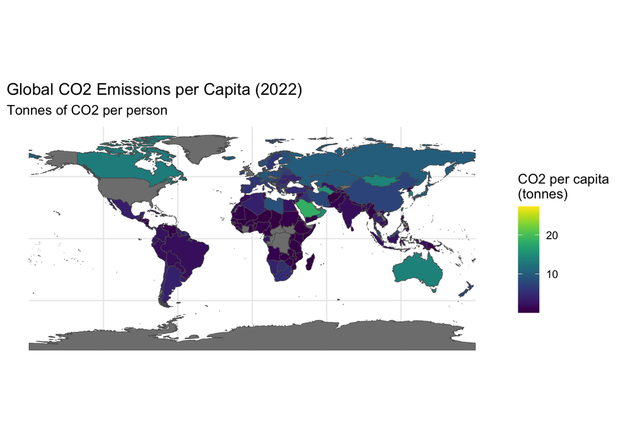

## GDP per Capita (2022)

[figure not shown]

## Relationship Analysis

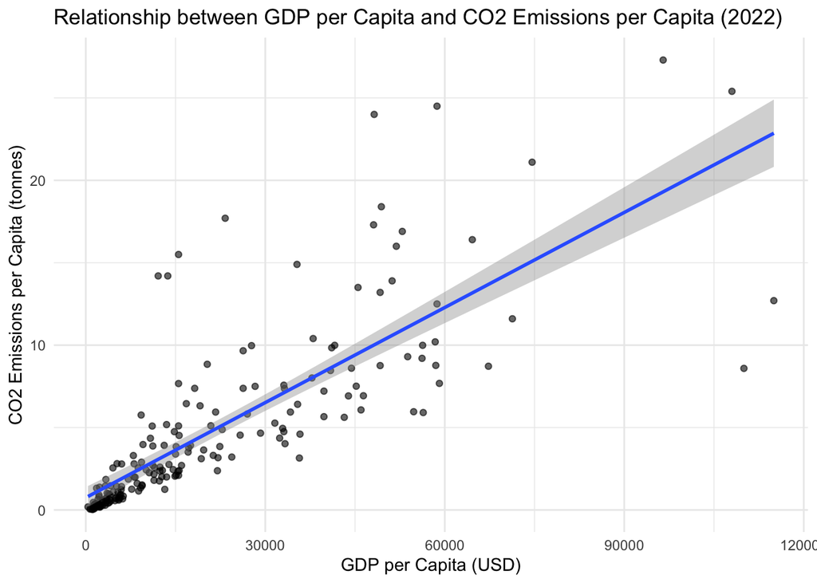

```
## Pearson's correlation coefficient (r): 0.792
```

## Interpretation

The scatter plot shows a positive relationship between GDP per Capita and CO2 Emissions per Capita, with a correlation coefficient of 0.792. This indicates that countries with higher GDP per capita tend to have higher CO2 emissions per person. This relationship is likely due to several factors:

1. Higher income levels often correlate with increased energy consumption
2. More developed economies typically have higher industrial activity
3. Wealthier nations often have higher levels of transportation and consumption

However, it’s important to note that this relationship is not perfect, as some countries may have different energy mixes or environmental policies that affect their CO2 emissions regardless of their GDP levels.